← Eğitim Listesine Geri Dön

# İstatistik Nedir?

2025-05-18

istatistik veri bilimi karar verme

# 📊 İstatistik Nedir? Sayıların Anlamına Giden Yol

## Giriş: Sayılar Sessizdir, İstatistik Konuşur

Diyelim ki elinde 1000 satır veri var.  
Sayılar karışık, anlamları yok gibi görünüyor.  
Ama sen sadece bir ortalama alıp medyanını bulduğun anda,  
verinin içindeki dengeyi görebiliyorsun.

> “İstatistik, sayılara anlam kazandıran bilimdir.

Bilgiye giden yolun ilk adımını atar.”

## Tanım: Bilimsel Yaklaşım ile Sayıları Okumak

**İstatistik**, verileri toplamak, düzenlemek, analiz etmek,  
ve bu verilerden anlamlı çıkarımlar yapmak için kullanılan bilimsel yöntemlerdir.

📌 Kullanım alanları:

- Veri bilimi
- Finansal analiz
- Tıp araştırmaları
- Kamuoyunu ölçme
- Pazarlama stratejisi

> “Veri ham demirdir.

İstatistik, onu bıçak haline getiren ustadır.”

## Neden İstatistik Öğrenmeliyiz?

| Sebep | Açıklama |
| --- | --- |
| ✅ Veriyi tanırız | Ortalama, dağılım, aykırı değerleri okuyabiliriz |
| ✅ Karar verirken dayanak olur | Strateji oluştururken sayısal temel sağlar |
| ✅ Tahmin yapabiliriz | Gelecek hakkında model kurabiliriz |
| ✅ Genellemeler yapabiliriz | Örnekten kitleye geçebiliriz |
| ✅ Hata payını biliriz | Ne kadar güvenebileceğimizi gösterir |

📌 İstatistik öğrenmeden veriyle çalışmak,  
**gözler kapalı harita çizmeye benzer.**

## Temel Amaçlar: Betimsel mi? Çıkarımsal mı?

### 🔹 Betimsel İstatistik (Descriptive Statistics)

Toplanan veriyi özetler, tanımlar.  
Ne olduğunu gösterir; nedenini değil.

#### Örnek:

```python
import numpy as np
import pandas as pd

df = pd.read_csv("data/satis_verisi.csv")
print(df.describe())
```

```
            Fiyat  SatisAdedi
count  100.000000  100.000000
mean   277.026200    9.320000
std    133.031241    5.557559
min     51.820000    1.000000
25%    161.825000    4.000000
50%    276.945000    9.500000
75%    384.412500   14.000000
max    497.600000   20.000000
```

✅ Ortalama, standart sapma, minimum-maksimum değerler  
→ Hepsi betimsel istatistiğe girer.

### 🔸 Çıkarımsal İstatistik (Inferential Statistics)

Örneklemden kitleye geçer.  
Tahmin yapar, hipotez test eder, ilişki kurar.

#### Örnek:

```python
from scipy.stats import ttest_1samp

orneklem = [70, 75, 80, 82, 85, 90]
t_stat, p_degeri = ttest_1samp(orneklem, popmean=75)
print(f"p-değeri: {p_degeri:.4f}")
```

```
p-değeri: 0.1259
```

📌 Eğer `p_değeri < 0.05` ise → ortalamanın farklı olduğunu söyler!

## 🧠 İstatistik Süreci: Hangi Adımları İzliyoruz?

| Aşama | Açıklama |
| --- | --- |
| 1. Araştırma Tasarımı | Soruları iyi sormak gerekir. Yoksa sonuç da yanlış olur. |
| 2. Veri Toplama | Kaynaklardan veri çekeriz. API, CSV, anket, sensör vs. |
| 3. Veri Düzenleme | Eksik değerleri doldurur, aykırı değerleri elemek zorunda kalırız. |
| 4. Betimsel Analiz | Ortalama, medyan, grafikler… Veriyi tanıyacağız. |
| 5. Çıkarımsal Analiz | Hipotez testi, regresyon, güven aralığı… Sonuçları genelleriz. |
| 6. Yorumlama | Sayılar konuşur, biz dinleriz. |
| 7. Raporlama | Bulduğumuz şeyleri başkalarına aktarırız. |

📌 Her aşama, sonraki aşamayı besler.  
Boş veri işe yaramaz, ama **doğru istatistikle her veri anlamlı hale gelir.**

## 👥 Ana Kütle mi? Örneklem mi?

| Terim | Açıklama |
| --- | --- |
| **Ana Kütle (Population)** | Üzerinde çalışmak istediğimiz tüm grup |
| **Örneklem (Sample)** | Ana kütleden seçilen küçük temsilci grubumuz |

📌 Gerçek hayatta ana kütlenin tamamına ulaşmak çok nadirdir.  
O yüzden örneklem alır, ondan yola çıkarak ana kütleyi tahmin ederiz.

## 🎯 Örneklem Seçimi: Rastgele mi? Kasıtlı mı?

| Tür | Açıklama |
| --- | --- |
| **Rassal Örnekleme** | Her bir elemanın seçilme şansı eşittir |
| **Tabakalı Örnekleme** | Gruplar arasında denge korunur |
| **Sistematik Örnekleme** | Belirli aralıklarla seçim yapılır |
| **Kolay Örnekleme** | Ulaşılması kolay olanlardan alınır → yanlı olabilir |

📌 Yanlı (biased) veri → Yanlı sonuç → Yanlı karar

> “Veri, eğer kitleyi yansıtmıyorsa,

ne kadar büyük olursa olsun → işe yaramaz.”

## 📈 Betimsel İstatistik: Veriyi Tanıyalım

### 1. Merkezi Eğilim Ölçüleri

```python
print("Ortalama:", df['Fiyat'].mean())
print("Medyan:", df['Fiyat'].median())
print("Mod:", df['Kategori'].mode()[0])
```

```
Ortalama: 277.0262
Medyan: 276.945
Mod: Elektronik
```

📌 Bu ölçüleri bildiğinde verinin merkezini görürsün.

2. Yayılım Ölçüleri

```python
print("Standart Sapma:", df['SatisAdedi'].std())
print("Değişim Aralığı:", df['SatisAdedi'].max() - df['SatisAdedi'].min())
print("Kartiller:", df['SatisAdedi'].quantile([0.25, 0.5, 0.75]))
```

```
Standart Sapma: 5.557559234633908
Değişim Aralığı: 19
Kartiller: 0.25     4.0
0.50     9.5
0.75    14.0
Name: SatisAdedi, dtype: float64
```

### 3. Görselleştirme

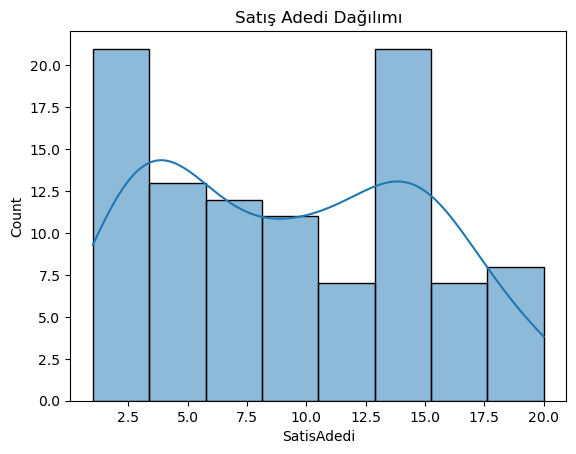

```python
import matplotlib.pyplot as plt
import seaborn as sns

sns.histplot(df['SatisAdedi'], kde=True)
plt.title("Satış Adedi Dağılımı")
plt.show()
```

📌 Görsel, sayıların hikâyesini anlatır.

## 🤔 Çıkarımsal İstatistik: Büyük Resmi Görelim

### 1. Güven Aralığı

```python
import scipy.stats as stats

satis_adetleri = df['SatisAdedi']
conf_int = stats.norm.interval(confidence=0.95,
                              loc=satis_adetleri.mean(),
                              scale=satis_adetleri.std() / np.sqrt(len(satis_adetleri)))

print(f"%95 Güven Aralığı: ({conf_int[0]:.2f}, {conf_int[1]:.2f})")
```

```
%95 Güven Aralığı: (8.23, 10.41)
```

📌 Bu aralıkta ana kütle parametresi olmalı.  
%95 ihtimalle…

2. Hipotez Testi

```python
from scipy.stats import ttest_1samp

orneklem_fiyat = df[df['Kategori'] == 'Elektronik']['Fiyat']
t_stat, p_val = ttest_1samp(orneklem_fiyat, popmean=300)

if p_val < 0.05:
    print("Elektronik ürünlerin fiyatı %95 güvenle 300’den farklı.")
else:
    print("Aradaki fark tesadüfi olabilir.")
```

```
Aradaki fark tesadüfi olabilir.
```

📌 Bu test, "gerçekten farklı mı?" sorusuna yanıt arar.

## 🧪 Veri Toplama Yöntemleri

| Yöntem | Açıklama |
| --- | --- |
| **Anketler (Survey)** | İnsanlardan doğrudan veri almak |
| **Deneyler (Experiment)** | Kontrollü ortamda veri üretmek |
| **Gözlem (Observation)** | Doğal ortamda izleme ve kaydetme |

📌 Deney yapıyorsan kontrol grubun olmalı.  
Yoksa sonuç ne kadar doğruysa da inandırıcı değildir.

## 📘 Betimsel mi, Çıkarımsal mı?

| Özellik | Betimsel | Çıkarımsal |
| --- | --- | --- |
| Amacı | Veriyi özetlemek | Örneklemi kullanarak kitle hakkında çıkarım yapmak |
| Veri | Tam veri seti | Örneklem |
| Güven | Kesin sonuç | Olasılığa dayalı sonuç |
| Model | Grafik, ortalama | Hipotez testi, regresyon, güven aralığı |

📌 Betimsel istatistik → veriyi okur  
Çıkarımsal istatistik → veriden yorum yapar

## 🧩 Gerçek Hayat Örneği: Satış Tahmini

Bir ürünün fiyat artışıyla satış sayısı düşer mi?

Bu soruya yanıt vermek için hem betimsel hem çıkarımsal istatistik kullanılır.

### Betimsel olarak bakalım:

```python
import pandas as pd

# Örnek veri yükleme
df_model = pd.read_csv("data/ornek_satis.csv")


print("Fiyat ortalaması:", df_model['fiyat'].mean())
print("Satış ortalaması:", df_model['satis'].mean())
```

```
Fiyat ortalaması: 261.5809
Satış ortalaması: 121.52
```

✅ Fiyat yükseldikçe satış azalıyor mu?

### Çıkarımsal olarak test edelim:

```python
from scipy.stats import pearsonr

r, p = pearsonr(df_model['fiyat'], df_model['satis'])
print(f"Pearson Korelasyonu: {r:.2f}, p-değeri: {p:.4f}")
```

```
Pearson Korelasyonu: -0.98, p-değeri: 0.0000
```

✅ Negatif korelasyon → ters yönlü ilişki  
✅ p < 0.05 → istatistiksel olarak anlamlı

## 🚨 Önemli Uyarı: Yanlılık (Bias)

Veri toplarken dikkat etmen gereken en önemli şey:  
**Veri, gerçek dünyayı yansıtıyor mu?**

📌 Yanlı veri toplarsan →  
yanlı analiz yaparsın →  
yanlı karar alırsın →  
yanlı sonuç elde edersin

> “İstatistiksel analiz, veriyle başlar.

Veri bozuksa, analiz de bozuktur.”

## 💡 Neden İstatistik Bilmeliyiz?

| Alan | İstatistik Rolü |
| --- | --- |
| **Veri Bilimi** | Model kurma, tahmin etme |
| **Finans** | Risk analizi, portföy optimizasyonu |
| **Sağlık** | Tedavi etkisi, hastalıkların yayılımı |
| **Eğitim** | Başarı oranları, eğitim yöntemi etkisi |
| **Pazarlama** | Müşteri davranışları, kampanya başarısı |

📌 İstatistik olmadan, veri sadece veri dizisidir.**  
İstatistikle beraber veri, **bilgiye dönüşür.**

## 📁 Sample Veri Seti: `ornek_satis.csv` ile Yapabileceklerimiz

Bu veriyle şu işlemleri yapabiliriz:

| İşlem | Açıklama |
| --- | --- |
| Korelasyon | Fiyat ve satış arasındaki ilişki |
| Regresyon | Fiyat artarsa satış miktarı nasıl değişir? |
| Histogram | Satış miktarı nasıl dağılmış? |
| Box Plot | Aykırı değer var mı? |
| Güven Aralığı | Gerçek ortalama nerdedir? |
| Hipotez Testi | Fiyat artışı gerçekten satışları düşürüyor mu? |

## 🧪 Python Kodu ile İstatistik Uygulaması

Şimdi örneklem üzerinden kitleye geçiş yapalım:

```python
import numpy as np
from scipy.stats import norm

# Ana kütle ortalaması bilinmiyor
# Örneklem alıyoruz ve güven aralığı hesaplıyoruz

orneklem = df_model.sample(n=30)
orneklem_ort = orneklem['satis'].mean()
orneklem_std = orneklem['satis'].std()
n = len(orneklem)

# %95 güven aralığı
z_skoru = 1.96
standart_hata = orneklem_std / np.sqrt(n)
alt_sinir = orneklem_ort - z_skoru * standart_hata
ust_sinir = orneklem_ort + z_skoru * standart_hata

print(f"%95 Güven Aralığı: ({alt_sinir:.2f}, {ust_sinir:.2f})")
```

```
%95 Güven Aralığı: (107.68, 136.52)
```

📌 Bu kod, örneklem üzerinden kitleye geçmenin nasıl yapıldığını gösteriyor.